# WEEK12

Graphical Analysis

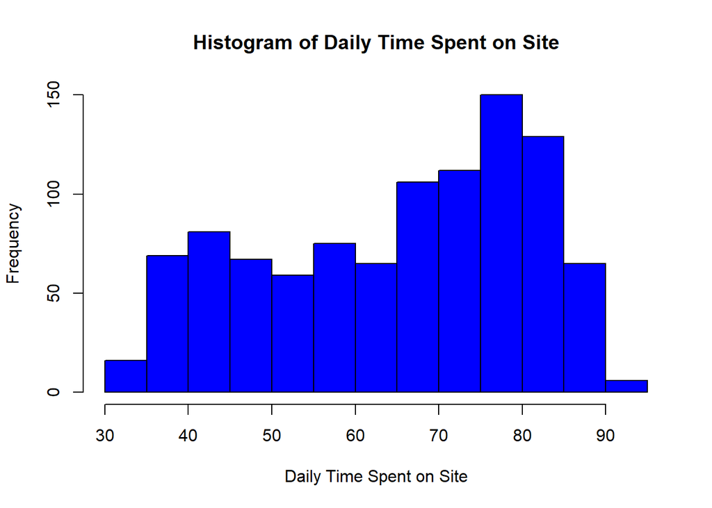

```r
hist(dataset[,1], main='Histogram of Daily Time Spent on Site',xlab='Daily Time Spent on Site',col='blue')
```

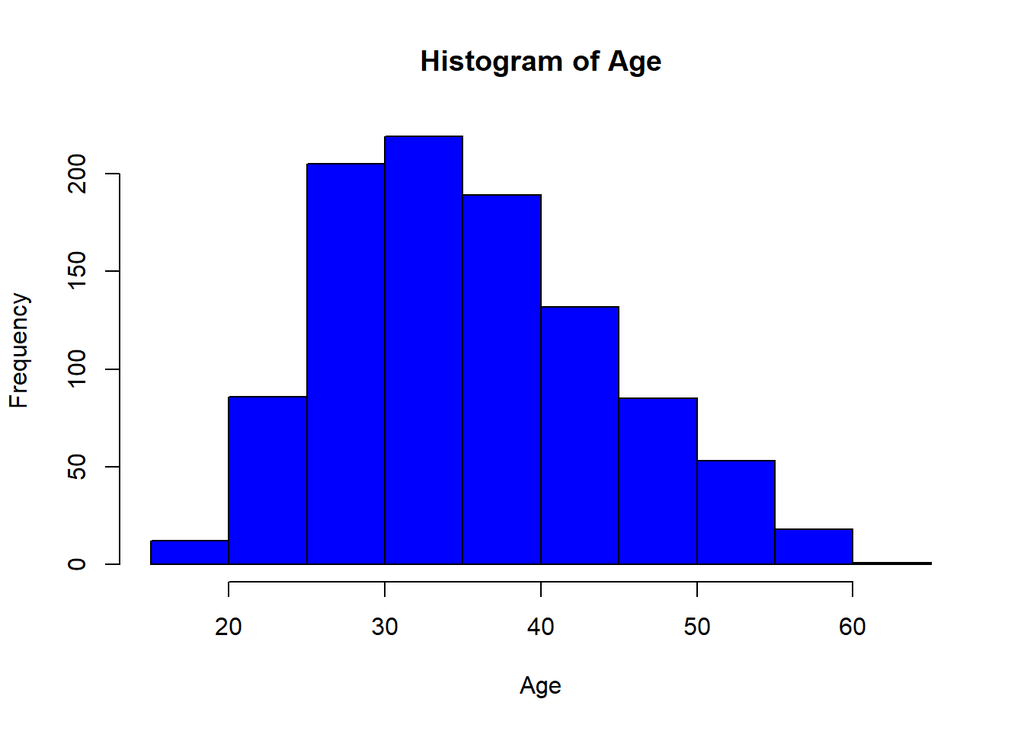

```r
# Age column
hist(dataset$Age, main='Histogram of Age', xlab='Age',col='blue')
```

From our histogram we can see that most of the people who visited the site are between the age 25 to 40.

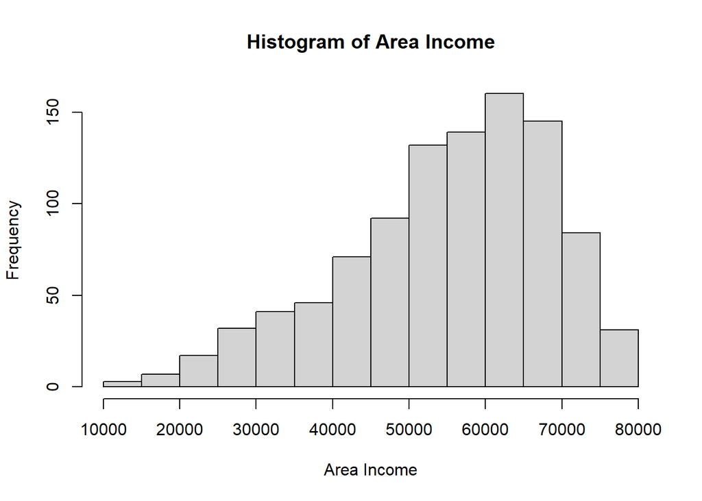

```r
# Area Income column
hist(dataset[,3],main='Histogram of Area Income',xlab='Area Income',çol='blue')
```

Most people who visited the site are in the 50,000 to 70,000 area income.

```r
# Male column
Male<- dataset[,7]
Male.frequency<-table(Male)
Male.frequency
```

```
## Male
##   0   1
## 519 481
```

0 represents females while 1 represents Males. From our frequency table most of the people who visited the site are females.

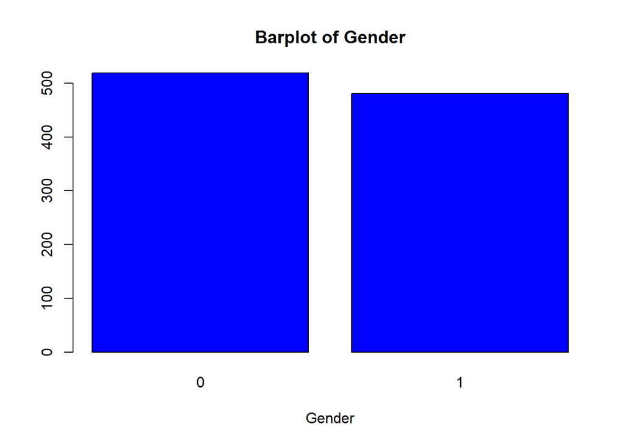

```r
# A barplot of the frequency distribution above.
barplot(Male.frequency, main='Barplot of Gender', xlab='Gender',col='blue')
```

```r
# Clicked on Ad column
clicked_on_Ad<- dataset[,10]
clicked_on_Ad.frequency<-table(clicked_on_Ad)
clicked_on_Ad.frequency
```

```
## clicked_on_Ad
##   0   1
## 500 500
```

0 represents those who didn’t click on the ad while 1 represents those who clicked on the ad.Half of the people who visited the site clicked on the Ad and half did not. Further evidence of no class imbalance.

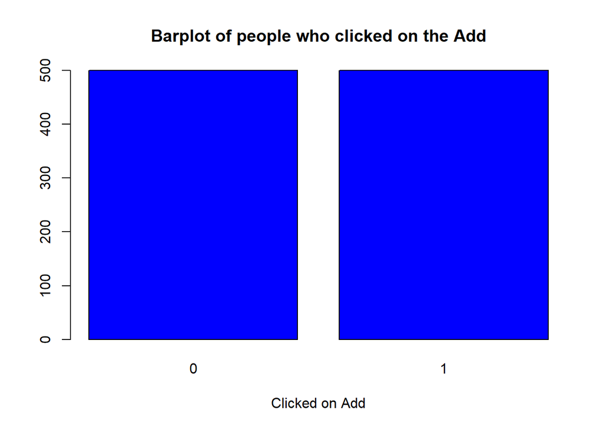

```r
# A barplot of the frequency distribution to describe this information.
barplot(clicked_on_Ad.frequency, main='Barplot of people who clicked on the Add', xlab='Clicked on Add',col='blue')
```

BIVARIATE ANALYSIS

```r
# Selecting our numerical variables to check the correlation.
numerical<-dataset[,1:4]
numerical <- cbind(numerical, dataset[c('Male')])
head(numerical)
```

```
##   Daily.Time.Spent.on.Site Age Area.Income Daily.Internet.Usage Male
## 1                    68.95  35    61833.90               256.09    0
## 2                    80.23  31    68441.85               193.77    1
## 3                    69.47  26    59785.94               236.50    0
## 4                    74.15  29    54806.18               245.89    1
## 5                    68.37  35    73889.99               225.58    0
## 6                    59.99  23    59761.56               226.74    1
```

```r
# Creating a correlation matrix
numerical.cor=cor(numerical,method=c('pearson'))
numerical.cor
```

```
##                          Daily.Time.Spent.on.Site         Age  Area.Income
## Daily.Time.Spent.on.Site               1.00000000 -0.33151334  0.310954413
## Age                                   -0.33151334  1.00000000 -0.182604955
## Area.Income                            0.31095441 -0.18260496  1.000000000
## Daily.Internet.Usage                   0.51865848 -0.36720856  0.337495533
## Male                                  -0.01895085 -0.02104406  0.001322359
##                          Daily.Internet.Usage         Male
## Daily.Time.Spent.on.Site           0.51865848 -0.018950855
## Age                               -0.36720856 -0.021044064
## Area.Income                        0.33749553  0.001322359
## Daily.Internet.Usage               1.00000000  0.028012326
## Male                               0.02801233  1.000000000
```

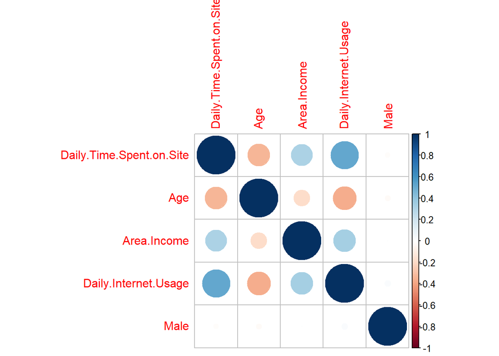

```r
# Installing the correlation plot to visualize the correlation coefficients.
library(corrplot)
corrplot(numerical.cor)
```

ScatterPlot

Creating a scatterplot to confirm any positive correlation between column ‘Daily Time Spent on Site’ and ‘Daily Internet Usage’.

```r
# Defining our variables
Time<-dataset[,1]
Internet<-dataset[,4]
```

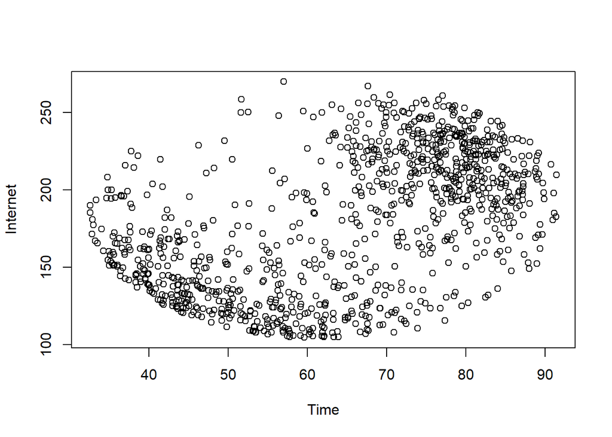

```r
plot(Time,Internet, xlab='Time',ylab='Internet')
```

MODELLING

```r
# Selecting our independent variables.
new<-dataset[,1:4]
new<- cbind(new, dataset[c('Male')])
head(new)
```

```
##   Daily.Time.Spent.on.Site Age Area.Income Daily.Internet.Usage Male
## 1                    68.95  35    61833.90               256.09    0
## 2                    80.23  31    68441.85               193.77    1
## 3                    69.47  26    59785.94               236.50    0
## 4                    74.15  29    54806.18               245.89    1
## 5                    68.37  35    73889.99               225.58    0
## 6                    59.99  23    59761.56               226.74    1
```

```r
# Scaling our independent variables.
new<-scale(new)
head(new)
```

```
##      Daily.Time.Spent.on.Site        Age Area.Income Daily.Internet.Usage
## [1,]                0.2491419 -0.1148475  0.50943618            1.7331628
## [2,]                0.9606516 -0.5701399  1.00202882            0.3136484
## [3,]                0.2819420 -1.1392555  0.35677007            1.2869451
## [4,]                0.5771428 -0.7977862 -0.01444841            1.5008289
## [5,]                0.2125572 -0.1148475  1.40816290            1.0382112
## [6,]               -0.3160289 -1.4807248  0.35495265            1.0646335
##            Male
## [1,] -0.9622138
## [2,]  1.0382307
## [3,] -0.9622138
## [4,]  1.0382307
## [5,] -0.9622138
## [6,]  1.0382307
```

```r
# Adding our target variable.
new<- cbind(new, dataset[c('Clicked.on.Ad')])
head(new)
```

```
##   Daily.Time.Spent.on.Site        Age Area.Income Daily.Internet.Usage
## 1                0.2491419 -0.1148475  0.50943618            1.7331628
## 2                0.9606516 -0.5701399  1.00202882            0.3136484
## 3                0.2819420 -1.1392555  0.35677007            1.2869451
## 4                0.5771428 -0.7977862 -0.01444841            1.5008289
## 5                0.2125572 -0.1148475  1.40816290            1.0382112
## 6               -0.3160289 -1.4807248  0.35495265            1.0646335
##         Male Clicked.on.Ad
## 1 -0.9622138             0
## 2  1.0382307             0
## 3 -0.9622138             0
## 4  1.0382307             0
## 5 -0.9622138             0
## 6  1.0382307             0
```

SVM

```r
# Installing caret for training our model.
library(caret)
# Splitting our data into train and test sets.
set.seed(42)
intrain <- createDataPartition(y = new$Clicked.on.Ad, p= 0.8, list = FALSE)
training <- new[intrain,]
testing <- new[-intrain,]
```

```r
# Checking the dimensions in our train and test sets.
dim(training);
```

```
## [1] 800   6
```

```r
dim(testing);
```

```
## [1] 200   6
```

```r
# Factorizing our target variable to convert the values(0 and 1) to categorical variables.

training[["Clicked.on.Ad"]] = factor(training[["Clicked.on.Ad"]])
```

```r
# Cross validating before training our model.

trctrl <- trainControl(method = "repeatedcv", number = 10, repeats = 3)
```

```r
# Training our model.

svm_Linear <- train(Clicked.on.Ad ~., data = training, method = "svmLinear",
trControl=trctrl,
preProcess = c("center", "scale"),
tuneLength = 10)
```

```r
# Predicting results in our testing data and checking the accuracy and classification matrix to evaluate the model's performance.
test_pred <- predict(svm_Linear, newdata = testing)
confusionMatrix(table(test_pred, testing$Clicked.on.Ad))
```

```
## Confusion Matrix and Statistics
##
##
## test_pred  0  1
##         0 97  5
##         1  3 95
##
##                Accuracy : 0.96
##                  95% CI : (0.9227, 0.9826)
##     No Information Rate : 0.5
##     P-Value [Acc > NIR] : <2e-16
##
##                   Kappa : 0.92
##
##  Mcnemar's Test P-Value : 0.7237
##
##             Sensitivity : 0.9700
##             Specificity : 0.9500
##          Pos Pred Value : 0.9510
##          Neg Pred Value : 0.9694
##              Prevalence : 0.5000
##          Detection Rate : 0.4850
##    Detection Prevalence : 0.5100
##       Balanced Accuracy : 0.9600
##
##        'Positive' Class : 0
##
```

We have a high accuracy score of 96%. From our classification matrix we have 5 false positives and 3 false negatives.

Naive Bayes

```r
# Converting the output variable into a categorical variable
new$Clicked.on.Ad <- factor(new$Clicked.on.Ad, levels = c(0,1), labels = c("False", "True"))
```

```r
# Splitting data into training and test data sets
set.seed(42)
indxTrain <- createDataPartition(y = new$Clicked.on.Ad,p = 0.8,list = FALSE)
training <- new[indxTrain,]
testing <- new[-indxTrain,]
```

```r
# x holds the predictor variables and y holds the response variable
x = training[,-6]
y = training$Clicked.on.Ad
```

```r
# Loading the library that holds the Naive Bayes function.
library(e1071)
# Cross validating and building our model.
model = train(x,y,'nb',trControl=trainControl(method='cv',number=10))
```

```r
# Predicting the test set.
Predict <- predict(model,newdata = testing )
```

```r
# Checking the model accuracy and the confusion matrix.
confusionMatrix(Predict, testing$Clicked.on.Ad )
```

```
## Confusion Matrix and Statistics
##
##           Reference
## Prediction False True
##      False    96    5
##      True      4   95
##
##                Accuracy : 0.955
##                  95% CI : (0.9163, 0.9792)
##     No Information Rate : 0.5
##     P-Value [Acc > NIR] : <2e-16
##
##                   Kappa : 0.91
##
##  Mcnemar's Test P-Value : 1
##
##             Sensitivity : 0.9600
##             Specificity : 0.9500
##          Pos Pred Value : 0.9505
##          Neg Pred Value : 0.9596
##              Prevalence : 0.5000
##          Detection Rate : 0.4800
##    Detection Prevalence : 0.5050
##       Balanced Accuracy : 0.9550
##
##        'Positive' Class : False
##
```

Our Naive Bayes model has a high accuracy score of 95.5%. From our classification matrix we have 5 False Positives and 4 False Negatives.

CONCLUSION

RECOMMENDATIONS

Since most of the people who visited the blog are between the age 25 to 40, she should create more blogs which most 25 to 40 year olds are interested in reading. This would attract more people to the blog bringing the ad more exposure.

Offering discounts on the course would benefit people from the higher income areas and also from the lower income areas. considering most people who visit the blog are on the higher side of the Income area, offering a discount increases the probability of these individuals clicking on the add than individuals in the lower income area since they are more exposed to the blog. Offering discounts will also help increase the chances of a person from a lower income area clicking on the add. Few from the lower income area might visit the blog, but some of them might join the course because of the discount.

Since most people who visit her blog are from high income areas, she should try targeting more audiences from high income areas(High Income countries). This would expose more people to her blog increasing the chances of people clicking on her ad.

Most of the people who visited the blog are females. She should therefore target audiences in areas with more females than males. Females are more likely to visit her blog than males.

Since most of the people who visited her blog were between 25 to 40 years old, she should target audiences in areas with this age group which would expose more people to her blog which would then increase her ad’s exposure.